# CIND119 PROJECT

9/21/2020

# Data Description

Includes Descriptive statistics of the working dataset, number of attributes, correlation between attributes, interesting trends (such as outliers and possible reasons), etc.

The data contains 1000 observations, 20 independent variables and 1 dependent outcome variable (the class attribute:Creditability). Variable descriptions can be referenced in the project description file.

Below is the structure build of the dataset (NOTE: Some data types are transformed in Weka):

```
## 'data.frame':    1000 obs. of  21 variables:
##  $ Creditability                    : Factor w/ 2 levels "Bad","Good": 2 2 2 2 2 2 2 2 2 2 ...
##  $ Account.Balance                  : Factor w/ 4 levels "< 0 DM","> 200 DM",..: 1 1 3 1 1 1 1 1 4 3 ...
##  $ Duration.of.Credit..month.       : int  18 9 12 12 12 10 8 6 18 24 ...
##  $ Payment.Status.of.Previous.Credit: Factor w/ 5 levels "all credits at this bank paid back duly",..: 2 2 4 2 2 2 2 2 2 4 ...
##  $ Purpose                          : Factor w/ 10 levels "Business","Domestic Appliances",..: 4 5 1 5 5 5 5 5 7 7 ...
##  $ Credit.Amount                    : int  1049 2799 841 2122 2171 2241 3398 1361 1098 3758 ...
##  $ Value.Savings.Stocks             : Factor w/ 5 levels "< 100 DM","=>1000 DM",..: 1 1 3 1 1 1 1 1 1 4 ...
##  $ Length.of.current.employment     : Factor w/ 5 levels "< 1 year",">=7years",..: 1 3 4 3 3 1 4 1 5 5 ...
##  $ Instalment.per.cent              : int  4 2 2 3 4 1 1 2 4 1 ...
##  $ Sex...Marital.Status             : Factor w/ 4 levels "female: divorced/separated/married",..: 1 4 1 4 4 4 4 4 1 1 ...
##  $ Guarantors                       : Factor w/ 3 levels "co-applicant",..: 3 3 3 3 3 3 3 3 3 3 ...
##  $ Duration.in.Current.address      : Factor w/ 4 levels "<= 1 year",">4years",..: 2 3 2 3 2 4 2 2 2 2 ...
##  $ Most.valuable.available.asset    : Factor w/ 4 levels "car or other",..: 3 2 2 2 3 2 2 2 1 4 ...
##  $ Age..years.                      : int  21 36 23 39 38 48 39 40 65 23 ...
##  $ Concurrent.Credits               : Factor w/ 3 levels "bank","none",..: 2 2 2 2 1 2 2 2 2 2 ...
##  $ Type.of.apartment                : Factor w/ 3 levels "for free","own",..: 3 3 3 3 2 3 2 2 2 3 ...
##  $ No.of.Credits.at.this.Bank       : int  1 2 1 2 2 2 2 1 2 1 ...
##  $ Occupation                       : Factor w/ 4 levels "management/ self-employed/highly qualified employee/ officer",..: 2 2 4 4 4 4 4 4 3 3 ...
##  $ No.of.dependents                 : int  1 2 1 2 1 2 1 2 1 1 ...
##  $ Telephone                        : Factor w/ 2 levels "No","Yes": 2 2 2 2 2 2 2 2 2 2 ...
##  $ Foreign.Worker                   : Factor w/ 2 levels "No","Yes": 2 2 2 1 1 1 1 1 2 2 ...
```

Below is the summary of the dataset:

```
##  Creditability            Account.Balance Duration.of.Credit..month.
##  Bad :300      < 0 DM             :274    Min.   : 4.0
##  Good:700      > 200 DM           : 63    1st Qu.:12.0
##                0 <=...<200 DM     :269    Median :18.0
##                No checking account:394    Mean   :20.9
##                                           3rd Qu.:24.0
##                                           Max.   :72.0
##
##                         Payment.Status.of.Previous.Credit
##  all credits at this bank paid back duly : 49
##  critical account                        :293
##  delay in paying off in the past         : 88
##  existing credits paid back duly till now:530
##  no credits taken                        : 40
##
##
##                 Purpose    Credit.Amount
##  Radio/Television   :280   Min.   :  250
##  New car            :234   1st Qu.: 1366
##  Furniture/Equipment:181   Median : 2320
##  Used car           :103   Mean   : 3271
##  Business           : 97   3rd Qu.: 3972
##  Education          : 50   Max.   :18424
##  (Other)            : 55
##                   Value.Savings.Stocks Length.of.current.employment
##  < 100 DM                   :603       < 1 year      :172
##  =>1000 DM                  : 48       >=7years      :253
##  100<= ... < 500 DM         :103       1<=...<4 years:339
##  500<= ... < 1000 DM        : 63       4<=...<7 years:174
##  unknown/ no savings account:183       unemployed    : 62
##
##
##  Instalment.per.cent                         Sex...Marital.Status
##  Min.   :1.000       female: divorced/separated/married:310
##  1st Qu.:2.000       male: divorced/separated          : 50
##  Median :3.000       male: married/widowed             : 92
##  Mean   :2.973       male: single                      :548
##  3rd Qu.:4.000
##  Max.   :4.000
##
```

[output cut: 25 more lines]

```
##  management/ self-employed/highly qualified employee/ officer:148
##  skilled employee / official                                 :630
##  unemployed/ unskilled - non-resident                        : 22
##  unskilled - resident                                        :200
##
##
##
##  No.of.dependents Telephone Foreign.Worker
##  Min.   :1.000    No :404   No : 37
##  1st Qu.:1.000    Yes:596   Yes:963
##  Median :1.000
##  Mean   :1.155
##  3rd Qu.:1.000
##  Max.   :2.000
##
```

# UNIVARIATE ANALYSIS

Some plots are presented to summarise each of the variables. Some quick graph information:

- The frequency by credit risk shows that the majority of applicants (700/70%) did not present any risk while 300 (30%) constituted a risk:

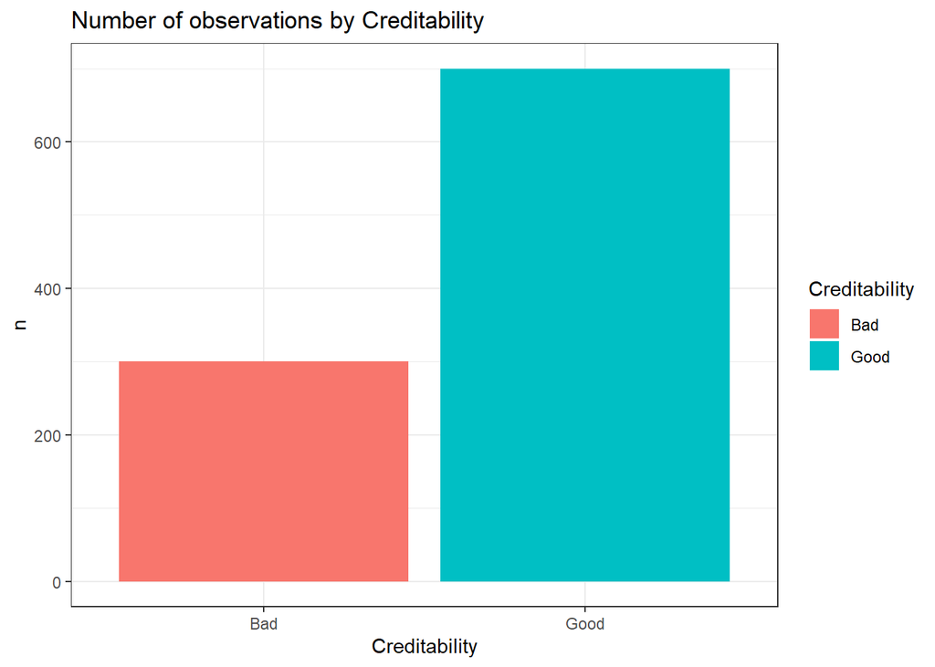

- The frequency by gender and marital status shows that the majority of borrowers are single males(548/54.8%), followed by females who were or are in a marital relationship(310/31%):

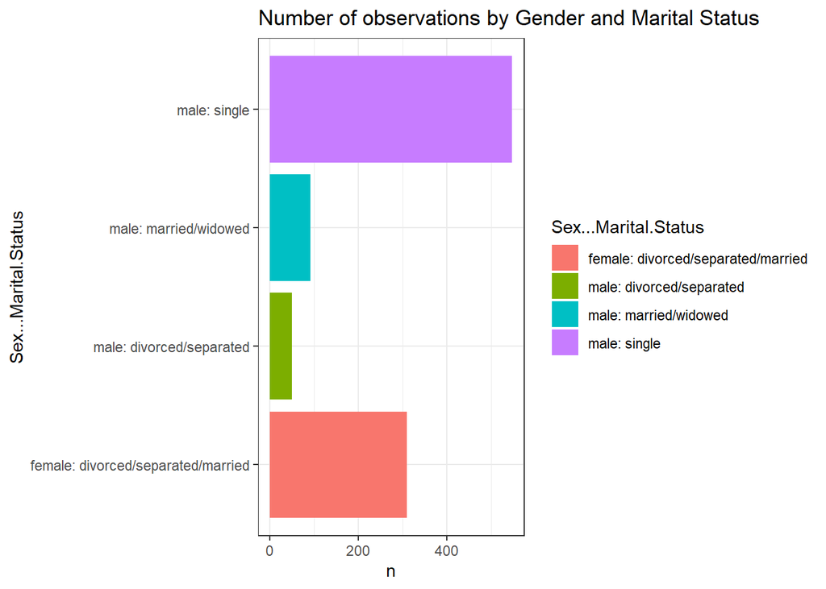

- The relative frequency by credit amount shows that the majority of borrowers applied for up to 5000 DM. While only a minority applied for a credit amount of more than 5000 DM:

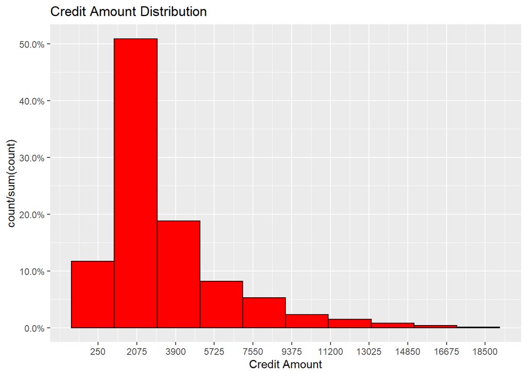

Credit values range between 250 DM and 18424 DM.

Mean of Credit Amount applied for: 3271.248

sdv of Credit Amount applied for: 2822.752 // High Standard deviation

We notice some potential outliers in the credit amount values mainly detected via IQR criterion in the boxplot:

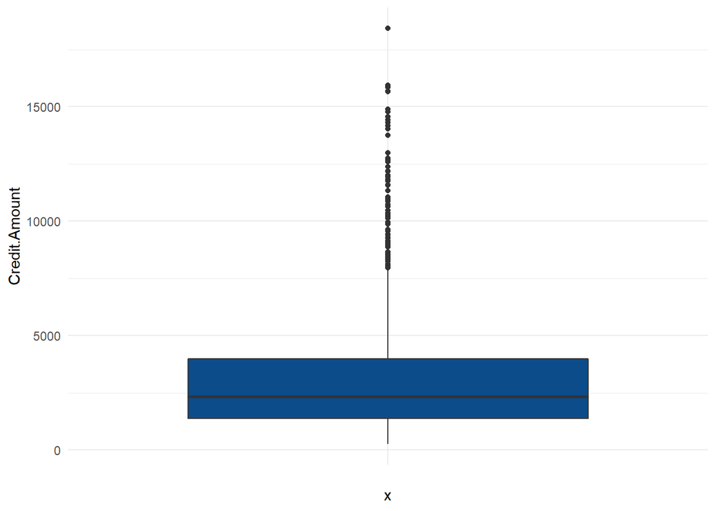

Since the tests we are going to apply are robust to the presence of outliers, we decided to keep them. This is reinforced by the context of our analysis as well as the fact these points are not extremely distant from other observations.

Below are the outlier values for the credit amount applied for:

```
##  [1] 10875  8858 12749  8072  8487 12169 10722  8613  8588 10366  8133  9436
## [13] 10477 13756 11760 14179 10974  9566  8358  9857 10222  9055  7966 12204
## [25]  8229 10623  9277 15857 10144 15653  8335  8471  8947 11054  9157  9283
## [37] 14555  9271  8386 14318 15672 10961  7980 11560 11328 11938 14782 12612
## [49]  9398  9572  8065  9034 14027  9629 12976 10297 14421  8086 10127 12389
## [61] 11590 15945  9960  8648  8318 11816 11998 18424 14896  8978 12579 12680
```

And these are their respective rows in the data frame:

```
##  [1]  64 153 180 183 193 209 219 224 233 242 296 310 356 383 427 443 522 526 557
## [20] 567 570 572 573 576 601 617 621 646 691 696 701 703 724 729 730 731 755 774
## [39] 781 783 811 821 833 836 844 845 848 850 868 874 888 890 891 892 896 929 930
## [58] 940 941 944 954 963 966 967 972 974 976 977 978 987 992 998
```

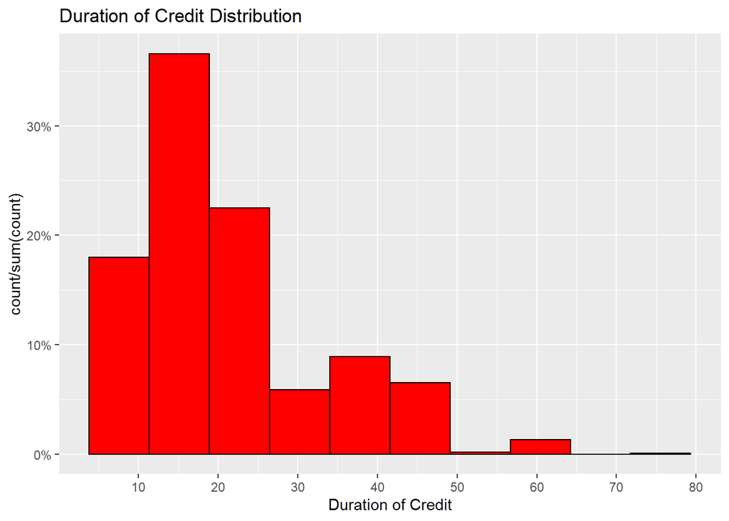

Credit duration values range between 4 and 72 months.

Mean of Credit Duration: 21

sdv of Credit Duration: 12 // High Standard deviation

We notice some potential outliers in the credit duration values as well mainly detected via IQR criterion in the boxplot:

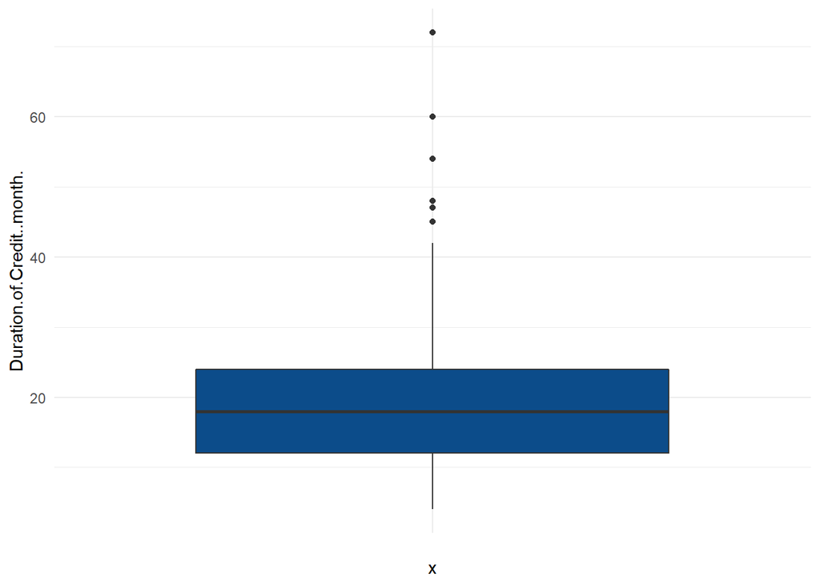

Below are the outlier occurences for the credit duration:

```
##  [1] 48 48 48 48 48 48 48 48 47 48 60 54 48 48 60 48 60 48 48 60 48 48 48 48 48
## [26] 48 60 60 45 48 48 48 72 48 60 60 48 60 60 48 60 48 48 48 60 45 48 48 48 48
## [51] 48 48 48 60 48 48 48 48 48 48 45 48 54 48 45 48 45 48 48 48
```

And these are their respective rows in the data frame:

```
##  [1]  14  63 153 159 180 193 200 209 219 230 242 310 312 353 383 406 456 542 557
## [20] 563 570 576 609 644 648 655 691 696 699 709 710 717 720 721 730 732 761 764
## [39] 808 811 812 821 827 830 848 851 856 861 862 871 878 883 886 891 910 919 920
## [58] 929 930 941 951 954 963 966 969 971 974 977 983 985
```

- The relative frequency by Account Balance shows that the majority of borrowers have no bank account or a negative account balance.

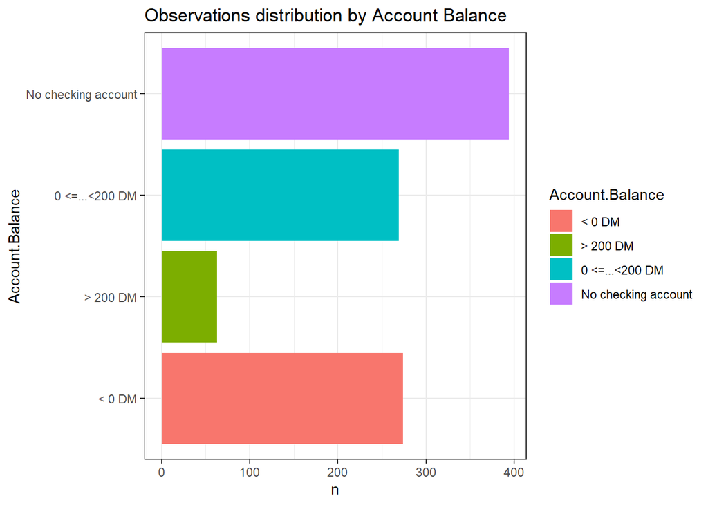

The Observations distribution by Value of Savings/Stocks shows most debtors having a savings/stocks value of less than < 100 DM. This is followed by debtors who have no savings or that the status of such is unknown.

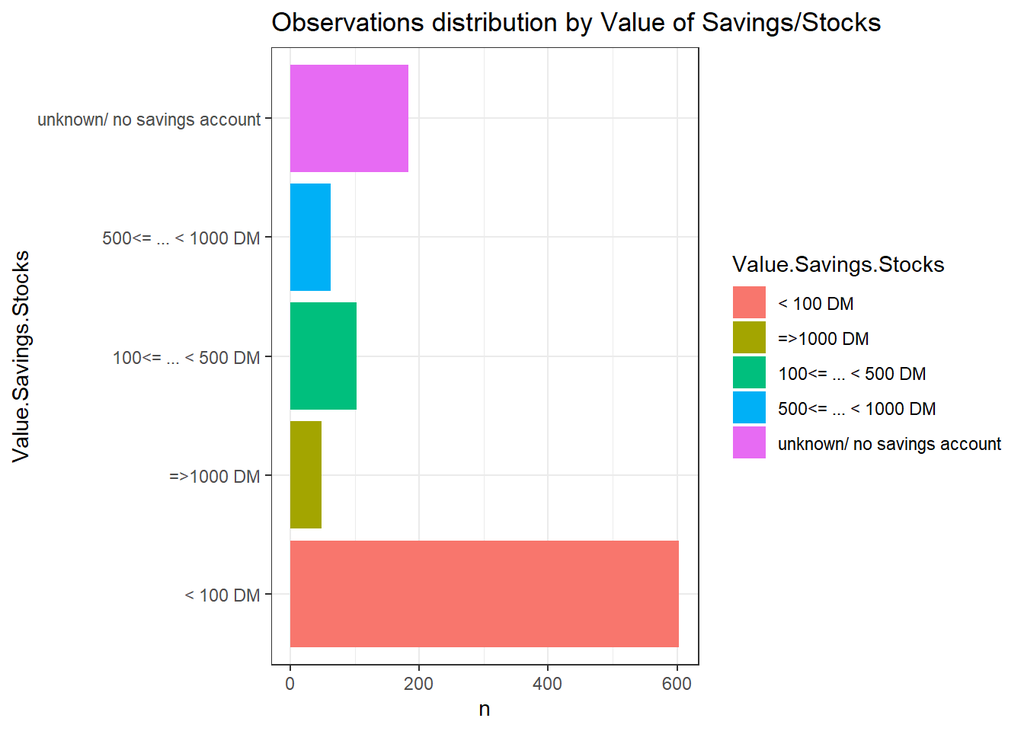

- The frequency by age shows that the majority of borrowers are in their mid twenties and early forties:

```
##         age.freq
## [19,27)      239
## [27,35)      308
## [35,43)      220
## [43,51)      120
## [51,59)       59
## [59,67)       41
## [67,75)       11
```

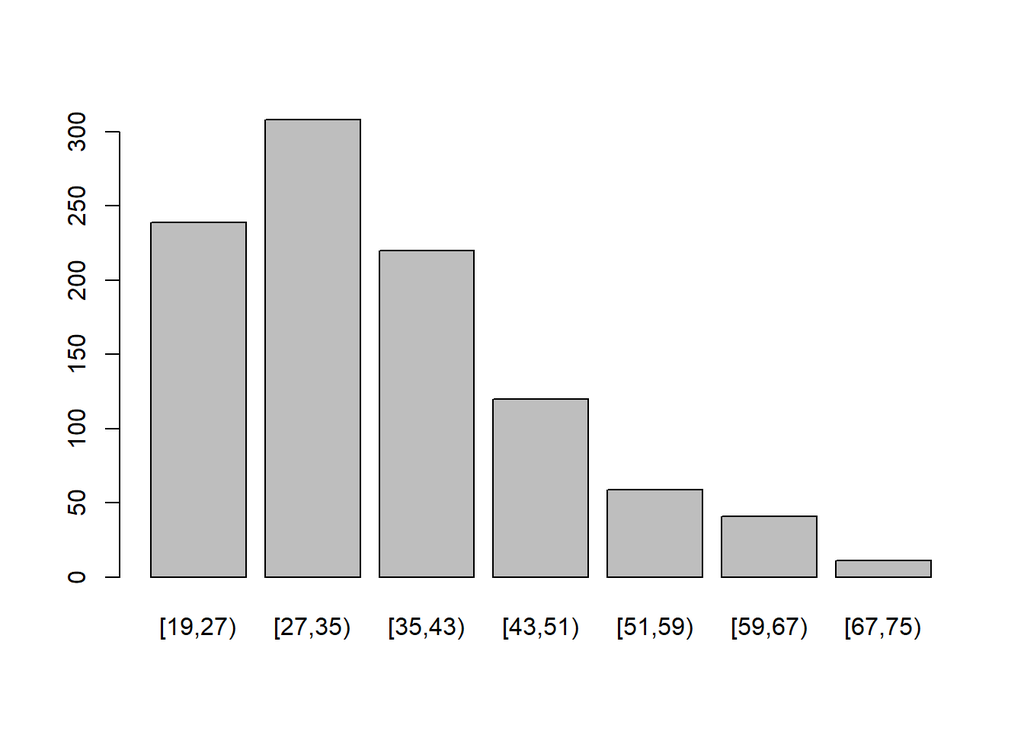

- The most common purpose of credit is to purchase a television/radio followed by purchase of new car then furniture then used car:

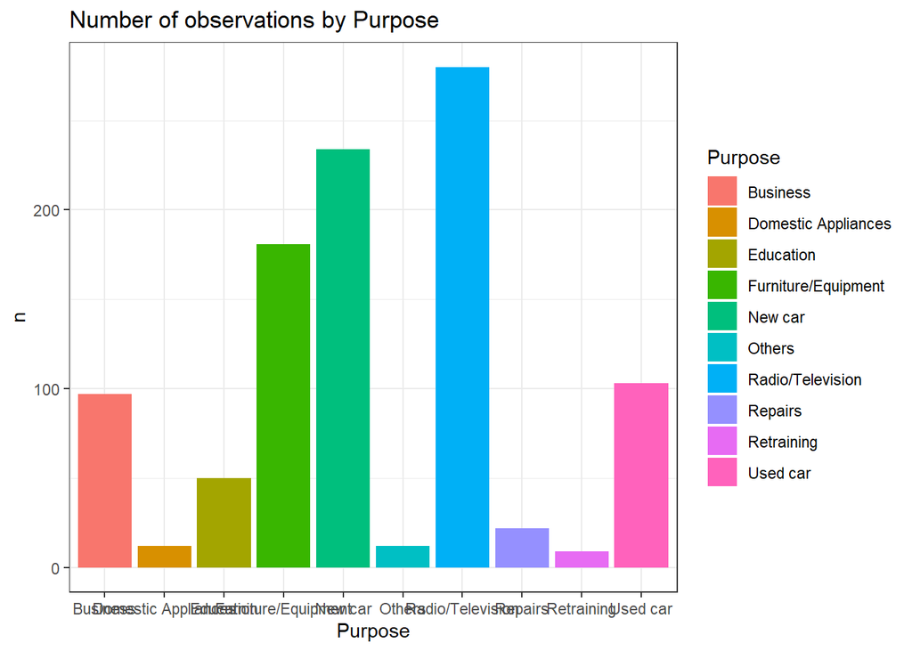

- The majority of borrowers have been duly paying their credits back so far(53%). Those with a critical account constitutes the second largest portion (29.3%):

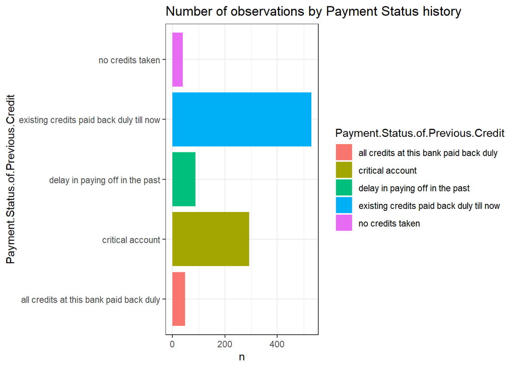

- Between 1 year and less than 4 years is the most frequent length of current employment. (33.9%), followed by those who are stable in their jobs for 7 years or more (25.3%). The unemployed are the smallest portion of applicants (6.2%):

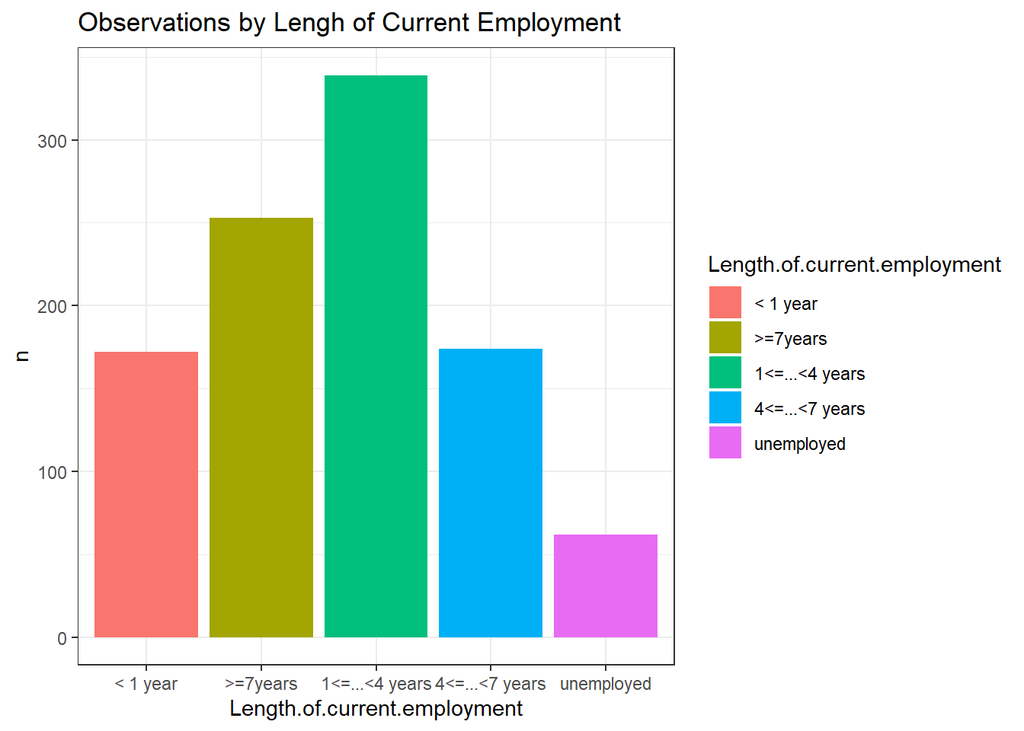

- Most of the applicants did not indicate any guarantor (90.7%). That could be explained by the fact most of them are foreign workers (96.3%):

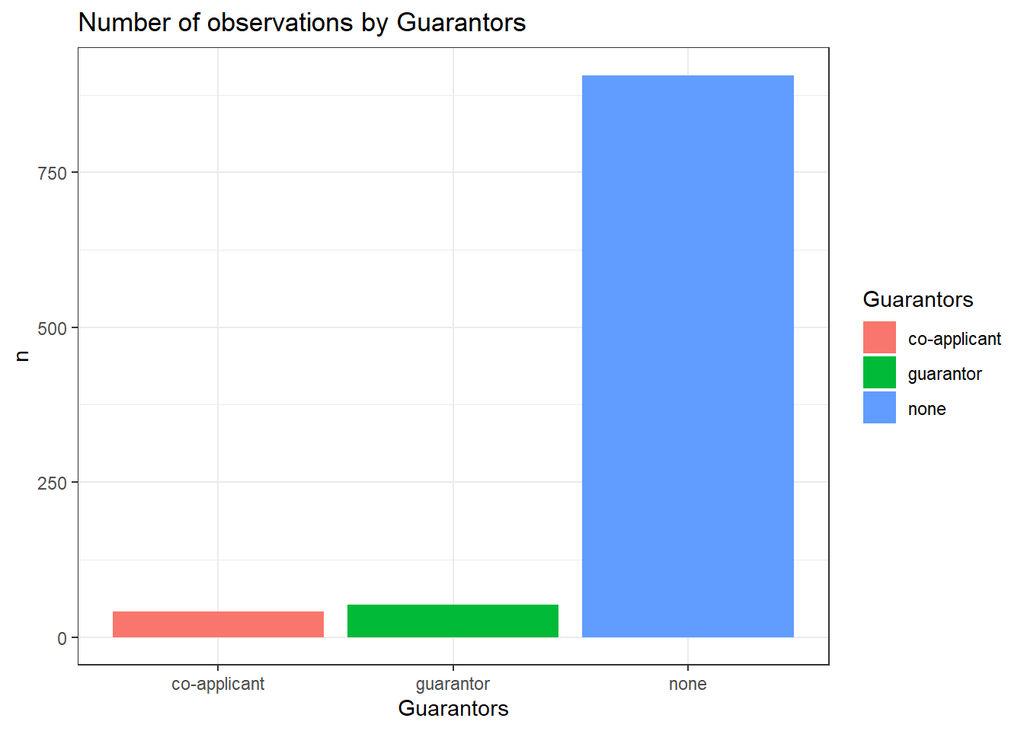

Foreign workers make the maojority of applicants:

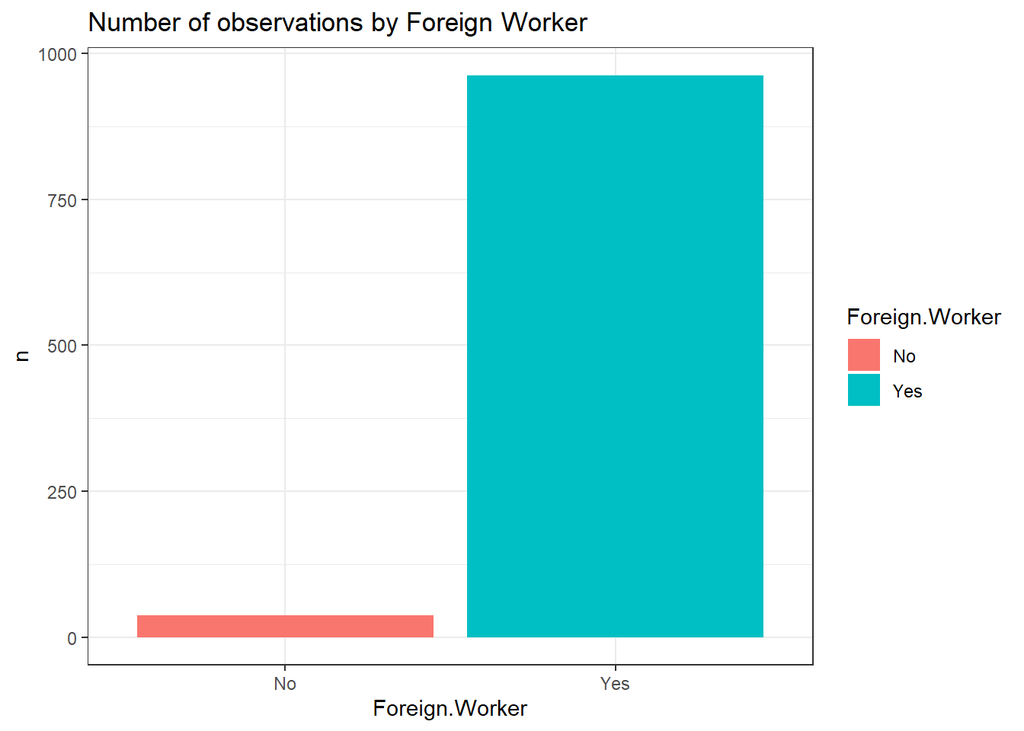

# BIVARIATE ANALYSIS

On this section we are going to compare the Creditability score (status) in relation to some potential explanatory variables,

[output not shown]

- Correlation of Creditability with Credit Amount:

```
## [1] -0.1547401
```

Note: Creditability was transformed into numerical (0 for Bad and 1 for Good)

Correlation of Creditability with age:

```
## [1] 0.09127195
```

Correlation of Creditability with Credit Duration:

```
## [1] -0.2149267
```

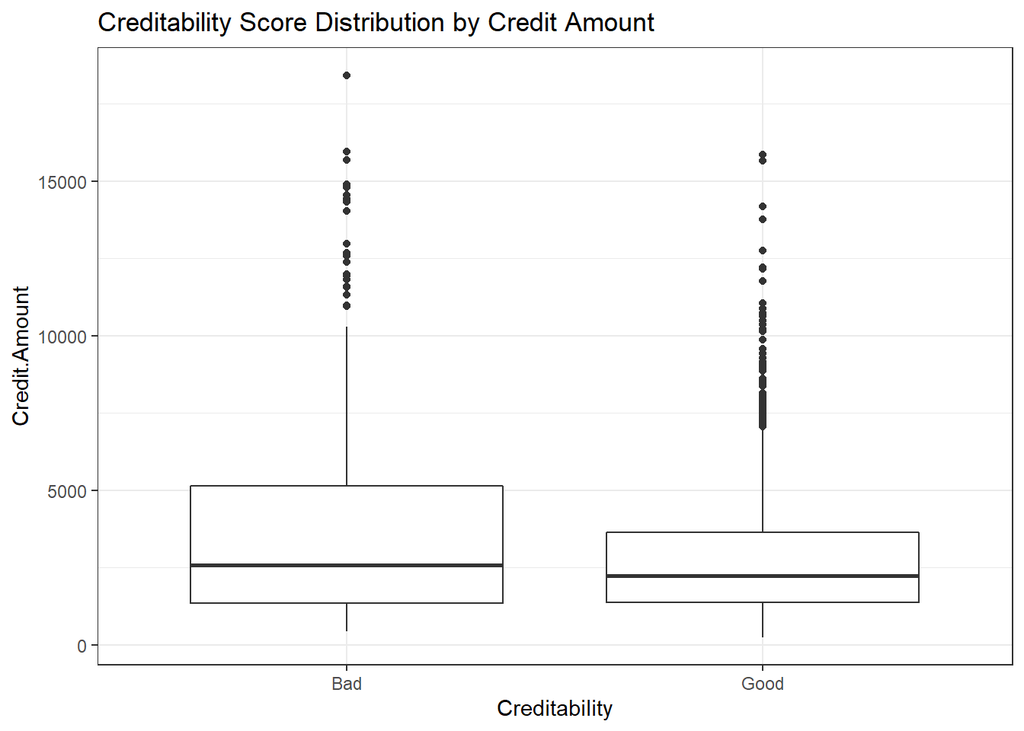

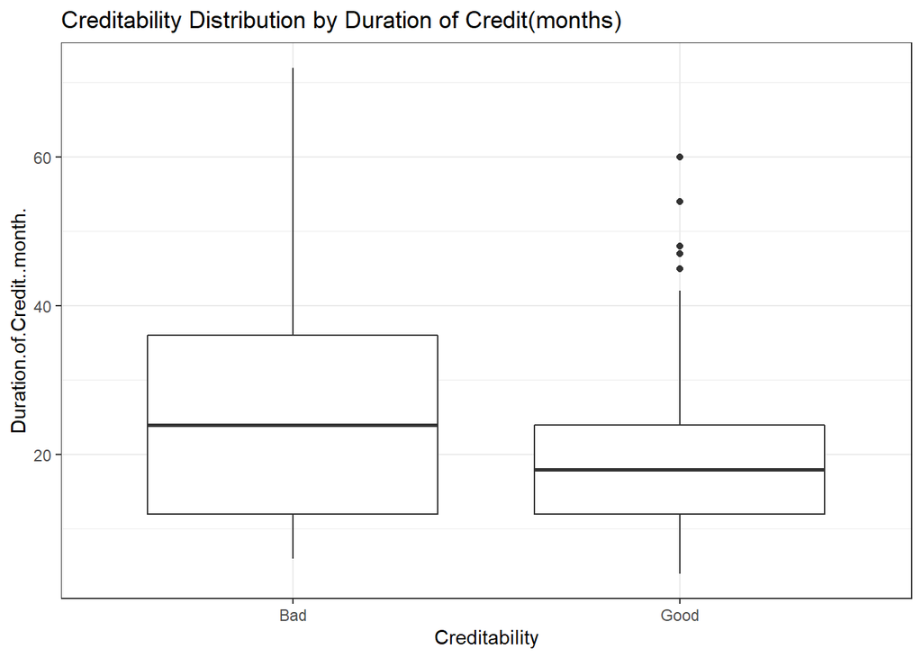